# Part I - Ford GoBike System Data

## by Abd Al-Muttalib Ibreighith

## Introduction

The dataset consists of 183,412 bike trip records collected from a bike-sharing program. It includes 16 features related to trip details, user information, and station locations. Below is a summary table of the dataset's columns:

| Column | Description |
| --- | --- |
| `duration_sec` | Duration of the trip in seconds |
| `start_time` | Timestamp for the start of the trip |
| `end_time` | Timestamp for the end of the trip |
| `start_station_id` | ID of the starting station |
| `start_station_name` | Name of the starting station |
| `start_station_latitude` | Latitude of the starting station |
| `start_station_longitude` | Longitude of the starting station |
| `end_station_id` | ID of the ending station |
| `end_station_name` | Name of the ending station |
| `end_station_latitude` | Latitude of the ending station |
| `end_station_longitude` | Longitude of the ending station |
| `bike_id` | ID of the bike used in the trip |
| `user_type` | Type of user (Customer or Subscriber) |
| `member_birth_year` | Birth year of the member |
| `member_gender` | Gender of the member |
| `bike_share_for_all_trip` | Whether the bike was shared for the entire trip (Yes/No) |

This dataset allows for a detailed analysis of bike usage patterns, user demographics, and station-specific details.

## Preliminary Wrangling

```python
# import all packages and set plots to be embedded inline
import numpy as np
import pandas as pd
import matplotlib.pyplot as plt
import seaborn as sns
```

### Load and Explore dataset

```python
df = pd.read_csv('201902-fordgobike-tripdata.csv')
```

```python
def print_info(dataframe):
    # Print the shape of df
    print(f'The shape of dataset is: {dataframe.shape}')
    print('------------------')
    # Print info
    print(f'The info of dataset is: \n{dataframe.info()}')
    print('------------------')
    # Print unique values
    print(f'The unique values of dataset are: \n{dataframe.nunique()}')
```

```python
print_info(df)
```

```
The shape of dataset is: (183412, 16)
------------------
<class 'pandas.core.frame.DataFrame'>
RangeIndex: 183412 entries, 0 to 183411
Data columns (total 16 columns):
 #   Column                   Non-Null Count   Dtype
---  ------                   --------------   -----
 0   duration_sec             183412 non-null  int64
 1   start_time               183412 non-null  object
 2   end_time                 183412 non-null  object
 3   start_station_id         183215 non-null  float64
 4   start_station_name       183215 non-null  object
 5   start_station_latitude   183412 non-null  float64
 6   start_station_longitude  183412 non-null  float64
 7   end_station_id           183215 non-null  float64
 8   end_station_name         183215 non-null  object
 9   end_station_latitude     183412 non-null  float64
 10  end_station_longitude    183412 non-null  float64
 11  bike_id                  183412 non-null  int64
 12  user_type                183412 non-null  object
 13  member_birth_year        175147 non-null  float64
 14  member_gender            175147 non-null  object
 15  bike_share_for_all_trip  183412 non-null  object
dtypes: float64(7), int64(2), object(7)
memory usage: 22.4+ MB
The info of dataset is:
None
------------------
The unique values of dataset are:
duration_sec                 4752
start_time                 183401
end_time                   183397
start_station_id              329
start_station_name            329
start_station_latitude        334
start_station_longitude       335
end_station_id                329
end_station_name              329
end_station_latitude          335
end_station_longitude         335
bike_id                      4646
user_type                       2
member_birth_year              75
member_gender                   3
bike_share_for_all_trip         2
dtype: int64
```

```python
# Print head of 5 rows
print('The head of dataset is:')
df.head()
```

```
The head of dataset is:
```

|  | duration_sec | start_time | end_time | start_station_id | start_station_name | start_station_latitude | start_station_longitude | end_station_id | end_station_name | end_station_latitude | end_station_longitude | bike_id | user_type | member_birth_year | member_gender | bike_share_for_all_trip |
| --- | --- | --- | --- | --- | --- | --- | --- | --- | --- | --- | --- | --- | --- | --- | --- | --- |
| 0 | 52185 | 2019-02-28 17:32:10.1450 | 2019-03-01 08:01:55.9750 | 21.0 | Montgomery St BART Station (Market St at 2nd St) | 37.789625 | -122.400811 | 13.0 | Commercial St at Montgomery St | 37.794231 | -122.402923 | 4902 | Customer | 1984.0 | Male | No |
| 1 | 42521 | 2019-02-28 18:53:21.7890 | 2019-03-01 06:42:03.0560 | 23.0 | The Embarcadero at Steuart St | 37.791464 | -122.391034 | 81.0 | Berry St at 4th St | 37.775880 | -122.393170 | 2535 | Customer | NaN | NaN | No |
| 2 | 61854 | 2019-02-28 12:13:13.2180 | 2019-03-01 05:24:08.1460 | 86.0 | Market St at Dolores St | 37.769305 | -122.426826 | 3.0 | Powell St BART Station (Market St at 4th St) | 37.786375 | -122.404904 | 5905 | Customer | 1972.0 | Male | No |
| 3 | 36490 | 2019-02-28 17:54:26.0100 | 2019-03-01 04:02:36.8420 | 375.0 | Grove St at Masonic Ave | 37.774836 | -122.446546 | 70.0 | Central Ave at Fell St | 37.773311 | -122.444293 | 6638 | Subscriber | 1989.0 | Other | No |
| 4 | 1585 | 2019-02-28 23:54:18.5490 | 2019-03-01 00:20:44.0740 | 7.0 | Frank H Ogawa Plaza | 37.804562 | -122.271738 | 222.0 | 10th Ave at E 15th St | 37.792714 | -122.248780 | 4898 | Subscriber | 1974.0 | Male | Yes |

### Clean the dataframe

But first we have to copy the df, so we reserve the original dataframe.

```python
# Copy the df for cleaning
df_clean = df.copy()
```

### Remove null values

First, let's find how many rows have at least 1 null value:

```python
# Print the number of rows that have at least 1 null value:
print(f'The number of rows that have at least 1 null value is: {df_clean.isnull().any(axis=1).sum()}')
```

```
The number of rows that have at least 1 null value is: 8460
```

Since they are not that much compared to the total rows, as follows:

num_rows_with_nulls_percentage = 8460/183412 = 4.6%

so let's remove them:

```python
# Remove rows have null values:
df_clean = df_clean[~df_clean.isnull().any(axis=1)]
```

Verify the changes:

```python
print(f'The info of dataset after the changes is: \n{df_clean.info()}')
```

```
<class 'pandas.core.frame.DataFrame'>
Int64Index: 174952 entries, 0 to 183411
Data columns (total 16 columns):
 #   Column                   Non-Null Count   Dtype
---  ------                   --------------   -----
 0   duration_sec             174952 non-null  int64
 1   start_time               174952 non-null  object
 2   end_time                 174952 non-null  object
 3   start_station_id         174952 non-null  float64
 4   start_station_name       174952 non-null  object
 5   start_station_latitude   174952 non-null  float64
 6   start_station_longitude  174952 non-null  float64
 7   end_station_id           174952 non-null  float64
 8   end_station_name         174952 non-null  object
 9   end_station_latitude     174952 non-null  float64
 10  end_station_longitude    174952 non-null  float64
 11  bike_id                  174952 non-null  int64
 12  user_type                174952 non-null  object
 13  member_birth_year        174952 non-null  float64
 14  member_gender            174952 non-null  object
 15  bike_share_for_all_trip  174952 non-null  object
dtypes: float64(7), int64(2), object(7)
memory usage: 22.7+ MB
The info of dataset after the changes is:
None
```

### Correct datatypes

Let's correct the data types of several columns in the DataFrame `df`. It converts `start_time` and `end_time` to datetime types, `start_station_id`, `end_station_id`, and `member_birth_year` to int64, and maps the `bike_share_for_all_trip` column from 'No' and 'Yes' to boolean values. So, we ensure consistency and reliable data.

```python
# Correct start_time and end_time datatypes into datetime type
df_clean['start_time'] = pd.to_datetime(df_clean['start_time'])
df_clean['end_time'] = pd.to_datetime(df_clean['end_time'])

# Correct ids datatypes into int64
df_clean['start_station_id'] = df_clean['start_station_id'].astype('int64')
df_clean['end_station_id'] = df_clean['end_station_id'].astype('int64')

# Correct member_birth_year datatype into int64
df_clean['member_birth_year'] = df_clean['member_birth_year'].astype('int64')

# Correct bike_share_for_all_trip(No=False/Yes=True) datatype into boolean
df_clean['bike_share_for_all_trip'] = df_clean['bike_share_for_all_trip'].map({'No': False, 'Yes': True})
```

Let's verify the datatypes and view the df_clean:

```python
print_info(df_clean)
```

```
The shape of dataset is: (174952, 16)
------------------
<class 'pandas.core.frame.DataFrame'>
Int64Index: 174952 entries, 0 to 183411
Data columns (total 16 columns):
 #   Column                   Non-Null Count   Dtype
---  ------                   --------------   -----
 0   duration_sec             174952 non-null  int64
 1   start_time               174952 non-null  datetime64[ns]
 2   end_time                 174952 non-null  datetime64[ns]
 3   start_station_id         174952 non-null  int64
 4   start_station_name       174952 non-null  object
 5   start_station_latitude   174952 non-null  float64
 6   start_station_longitude  174952 non-null  float64
 7   end_station_id           174952 non-null  int64
 8   end_station_name         174952 non-null  object
 9   end_station_latitude     174952 non-null  float64
 10  end_station_longitude    174952 non-null  float64
 11  bike_id                  174952 non-null  int64
 12  user_type                174952 non-null  object
 13  member_birth_year        174952 non-null  int64
 14  member_gender            174952 non-null  object
 15  bike_share_for_all_trip  174952 non-null  bool
dtypes: bool(1), datetime64[ns](2), float64(4), int64(5), object(4)
memory usage: 21.5+ MB
The info of dataset is:
None
------------------
The unique values of dataset are:
duration_sec                 4429
start_time                 174941
end_time                   174939
start_station_id              329
start_station_name            329
start_station_latitude        329
start_station_longitude       329
end_station_id                329
end_station_name              329
end_station_latitude          329
end_station_longitude         329
bike_id                      4607
user_type                       2
member_birth_year              75
member_gender                   3
bike_share_for_all_trip         2
dtype: int64
```

```python
# Print head of 5 rows
print('The head of dataset is:')
df.head()
```

```
The head of dataset is:
```

|  | duration_sec | start_time | end_time | start_station_id | start_station_name | start_station_latitude | start_station_longitude | end_station_id | end_station_name | end_station_latitude | end_station_longitude | bike_id | user_type | member_birth_year | member_gender | bike_share_for_all_trip |
| --- | --- | --- | --- | --- | --- | --- | --- | --- | --- | --- | --- | --- | --- | --- | --- | --- |
| 0 | 52185 | 2019-02-28 17:32:10.1450 | 2019-03-01 08:01:55.9750 | 21.0 | Montgomery St BART Station (Market St at 2nd St) | 37.789625 | -122.400811 | 13.0 | Commercial St at Montgomery St | 37.794231 | -122.402923 | 4902 | Customer | 1984.0 | Male | No |
| 1 | 42521 | 2019-02-28 18:53:21.7890 | 2019-03-01 06:42:03.0560 | 23.0 | The Embarcadero at Steuart St | 37.791464 | -122.391034 | 81.0 | Berry St at 4th St | 37.775880 | -122.393170 | 2535 | Customer | NaN | NaN | No |
| 2 | 61854 | 2019-02-28 12:13:13.2180 | 2019-03-01 05:24:08.1460 | 86.0 | Market St at Dolores St | 37.769305 | -122.426826 | 3.0 | Powell St BART Station (Market St at 4th St) | 37.786375 | -122.404904 | 5905 | Customer | 1972.0 | Male | No |
| 3 | 36490 | 2019-02-28 17:54:26.0100 | 2019-03-01 04:02:36.8420 | 375.0 | Grove St at Masonic Ave | 37.774836 | -122.446546 | 70.0 | Central Ave at Fell St | 37.773311 | -122.444293 | 6638 | Subscriber | 1989.0 | Other | No |
| 4 | 1585 | 2019-02-28 23:54:18.5490 | 2019-03-01 00:20:44.0740 | 7.0 | Frank H Ogawa Plaza | 37.804562 | -122.271738 | 222.0 | 10th Ave at E 15th St | 37.792714 | -122.248780 | 4898 | Subscriber | 1974.0 | Male | Yes |

### What is the structure of the dataset?

> There are `174,952` bike trips in the dataset with `16` features. Most variables are numeric in nature, such as `duration_sec`, `start_station_id`, `start_station_latitude`, `start_station_longitude`, `end_station_id`, `end_station_latitude`, `end_station_longitude`, `bike_id`, and `member_birth_year`. However, several variables are categorical or textual, including `start_time`, `end_time` (representing timestamps), `start_station_name`, `end_station_name` (station names), `user_type` (customer or subscriber), `member_gender` (gender of the member), and `bike_share_for_all_trip` (indicating whether the bike was shared for the entire trip).

### What are the main features of interest in the dataset?

> The main features of interest appear to be:
- `duration_sec`: This feature indicates the duration of each bike trip, which can provide insights into ride lengths and usage patterns.
- `start_time` and `end_time`: These features provide timestamps for the start and end of each trip, enabling analysis of temporal trends and peak usage times.
- `start_station_name` and `end_station_name`: These categorical features identify the starting and ending locations of each trip, useful for understanding popular routes and station utilization.
- `user_type`: This categorical feature distinguishes between customers and subscribers, offering insights into user demographics and behavior patterns.

These features collectively provide a comprehensive view of bike trip durations, temporal patterns, station usage, and user characteristics within your dataset.

### What features in the dataset will help to support the investigation of the features of interest?

> To investigate the features of interest in the dataset, several other features will support the analysis:
1. **Geospatial Features**: `start_station_latitude`, `start_station_longitude`, `end_station_latitude`, `end_station_longitude` can help visualize and analyze the geographic distribution of bike trips and station locations.
2. **Demographic Features**: `member_birth_year` and `member_gender` will aid in understanding the demographics of riders and how they correlate with trip characteristics.
3. **Temporal Features**: Besides `start_time` and `end_time`, additional temporal features such as day of the week, month, or season derived from timestamps can help uncover patterns in bike usage over time.
4. **Trip Specifics**: `bike_id` can track individual bikes and their usage patterns, while `bike_share_for_all_trip` indicates whether the bike was shared for the entire trip, potentially influencing trip duration and usage.
5. **Station Details**: Further details about stations such as `start_station_id` and `end_station_id` could provide additional context about station infrastructure or characteristics affecting trip patterns.

These features collectively provide context and additional dimensions to analyze and interpret the main features of interest in your dataset related to bike trip durations, user behaviors, and station usage patterns.

## Univariate Exploration

In this section, we investigate the distributions of individual variables. This helps in identifying unusual points or outliers and prepares us to explore relationships between variables.

### Question 1: What are the trip durations?

#### Visualization:

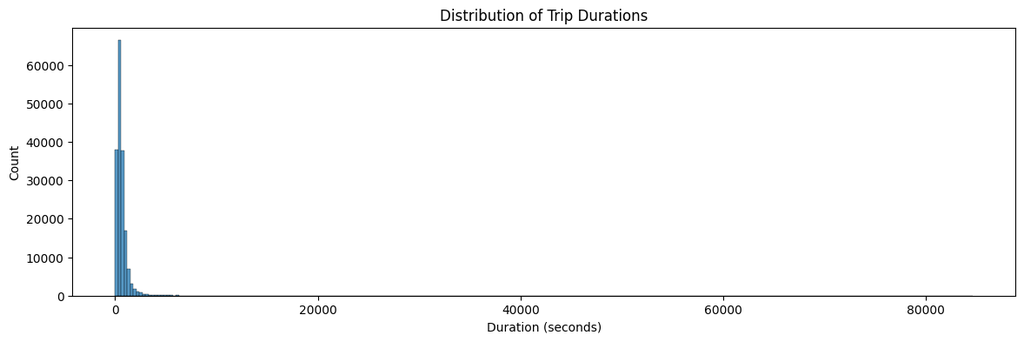

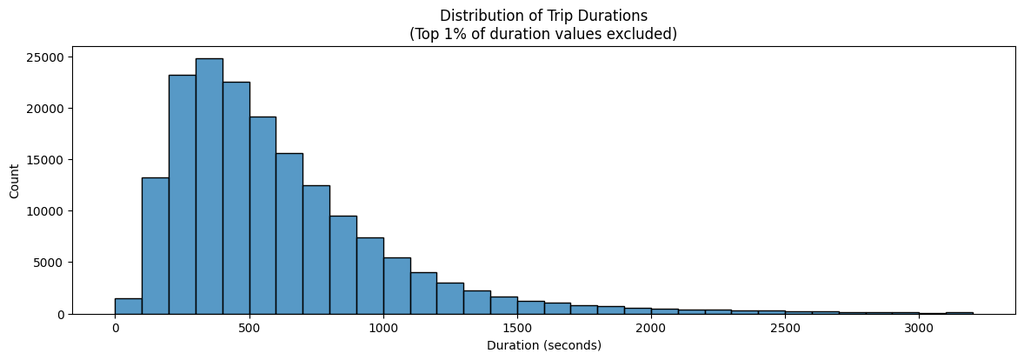

```python
# Plot the histogram for trip durations
plt.figure(figsize=(14, 4))
binsize = 300
bins = np.arange(0, df_clean['duration_sec'].max() + binsize, binsize)

sns.histplot(df_clean['duration_sec'], bins=bins)
plt.title('Distribution of Trip Durations')
plt.xlabel('Duration (seconds)')
plt.ylabel('Count')
plt.show()

# Plot the histogram for trip durations excluding outliers
plt.figure(figsize=(14, 4))
binsize = 100
bins = np.arange(0, df_clean['duration_sec'].quantile(0.99) + binsize, binsize)

sns.histplot(df_clean['duration_sec'], bins=bins)
plt.title('Distribution of Trip Durations\n(Top 1% of duration values excluded)')
plt.xlabel('Duration (seconds)')
plt.ylabel('Count')
plt.show()
```

#### Observations:

```python
def countplotter(x, data, hue, title, xlabel, ylabel):
    plt.figure(figsize=(8, 6))
    sns.countplot(x=x, data=data, hue=hue, palette='viridis')
    plt.title(title)
    plt.xlabel(xlabel)
    plt.ylabel(ylabel)
    plt.show()
```

### Question 2: What is the distribution of user types?

#### Visualization:

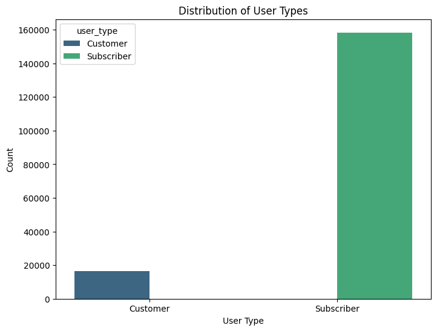

```python
# Plot the distribution of user types
countplotter('user_type', df_clean, 'user_type', 'Distribution of User Types', 'User Type', 'Count')
```

#### Observations:

- The dataset has two user types: Customers and Subscribers.
- Subscribers appear to be the majority user type compared to Customers.

### Question 3: How many riders shared their bikes vs didn't share?

#### Visualization:

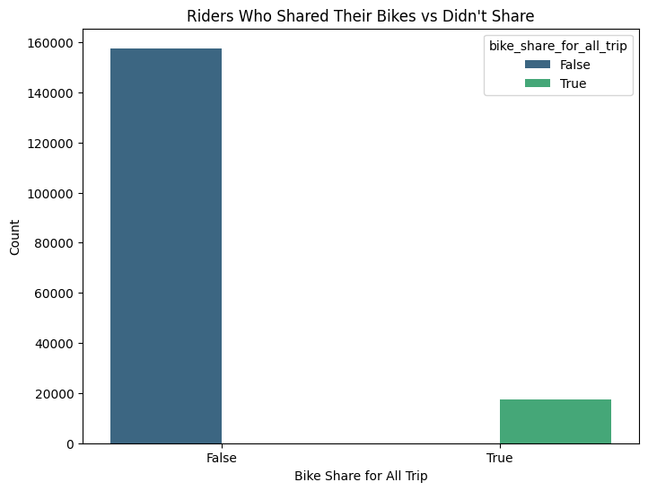

```python
# Plot the number of riders who shared vs didn't share their bikes
countplotter('bike_share_for_all_trip', df_clean, 'bike_share_for_all_trip', 'Riders Who Shared Their Bikes vs Didn\'t Share', 'Bike Share for All Trip', 'Count')
```

#### Observations:

- Most riders did not share their bikes for the entire trip.
- A smaller proportion of riders shared their bikes for the entire trip.

### Question 4: What is the distribution of the members' birth years?

#### Visualization:

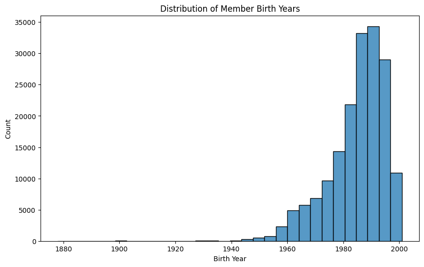

```python
# Plot the histogram for member birth years
plt.figure(figsize=(10, 6))
sns.histplot(df_clean['member_birth_year'], bins=30)
plt.title('Distribution of Member Birth Years')
plt.xlabel('Birth Year')
plt.ylabel('Count')
plt.show()
```

### Discuss the distribution(s) of your variable(s) of interest. Were there any unusual points? Did you need to perform any transformations?

#### Member Birth Years

The histogram of member birth years exhibits a left-skewed distribution, with most members born between the 1960s and 2000. The highest frequency is observed for members born around the late 1980s and early 1990s. A few outliers exist for birth years earlier than 1940, which might need further inspection to ensure data accuracy.

#### Bike Share for All Trip

The bar chart for bike sharing indicates that the majority of riders did not share their bikes for all trips. There is a significant disparity between those who shared and those who did not, with non-sharers vastly outnumbering sharers. No transformations were necessary for this variable.

#### User Types

The bar chart for user types shows that the dataset contains two types of users: customers and subscribers. Subscribers are more frequent than customers. This straightforward distribution did not require any transformations.

### Of the features you investigated, were there any unusual distributions? Did you perform any operations on the data to tidy, adjust, or change the form of the data? If so, why did you do this?

Of the features investigated, the member birth year distribution had some unusual points (outliers for birth years before 1940). These points could be due to data entry errors or older members who are outliers in the age distribution. No significant transformations were performed on these distributions, but it might be useful to clean the data by investigating and potentially removing these outliers to ensure the accuracy and reliability of the analysis.

No transformations were necessary for the bike sharing, and user type distributions.

## Bivariate Exploration

In this section, we will investigate relationships between pairs of variables in our dataset. We will use scatter plots, box plots, and clustered bar charts to visualize these relationships and gain deeper insights.

### Question 1: How does trip duration vary with start station and end station names?

#### Visualization:

[figure not shown]

```python
# Group by start_station_name and calculate the mean duration
start_station_duration = df_clean.groupby('start_station_name')['duration_sec'].mean().reset_index()
start_station_duration_pivot = start_station_duration.pivot_table(index='start_station_name', values='duration_sec')

# Plot the heatmap for start station names
plt.figure(figsize=(12, 10))
sns.heatmap(start_station_duration_pivot, cmap='Greys', fmt='.0f', cbar_kws={'label': 'Mean Duration (seconds)'})
plt.title('Mean Trip Duration Heatmap for Start Stations')
plt.xlabel('Mean Duration (seconds)')
plt.ylabel('Start Station Name')
plt.show()
```

#### Observations

- **Variation in Durations**: The heatmap reveals significant variation in mean trip durations across different start stations, with some stations showing higher durations than others.
- **High and Low Means**: Darker shades indicate stations with higher mean trip durations, possibly due to their location or usage patterns, while lighter shades indicate stations with shorter mean durations.
- **Station-Specific Patterns**: Individual stations show distinct mean durations, suggesting the need for station-specific analysis to understand factors influencing trip lengths.
- **Potential Outliers**: Extreme mean durations at certain stations suggest the presence of outliers or unique usage patterns, warranting further investigation.

[figure not shown]

```python
# Group by end_station_name and calculate the mean duration
end_station_duration = df_clean.groupby('end_station_name')['duration_sec'].mean().reset_index()
end_station_duration_pivot = end_station_duration.pivot_table(index='end_station_name', values='duration_sec')

# Plot the heatmap for end station names
plt.figure(figsize=(12, 10))
sns.heatmap(end_station_duration_pivot, cmap='Greys', fmt='.0f', cbar_kws={'label': 'Mean Duration (seconds)'})
plt.title('Mean Trip Duration Heatmap for End Stations')
plt.xlabel('Mean Duration (seconds)')
plt.ylabel('End Station Name')
plt.show()
```

### Question 2: How does trip duration vary with user type?

#### Visualization:

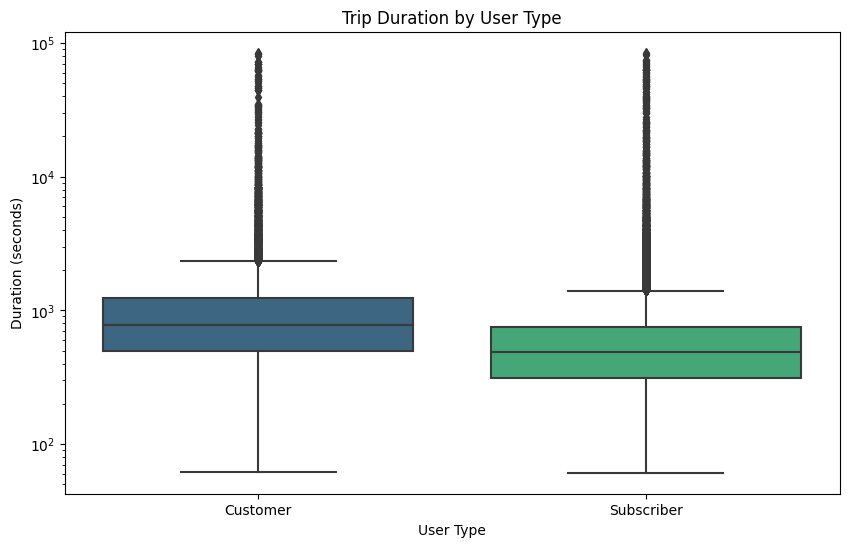

```python
# Box plot of trip duration by user type
plt.figure(figsize=(10, 6))
sns.boxplot(x='user_type', y='duration_sec', data=df_clean, palette='viridis')
plt.title('Trip Duration by User Type')
plt.xlabel('User Type')
plt.ylabel('Duration (seconds)')
plt.yscale('log')
plt.show()
```

#### Observations:

- Subscribers tend to have shorter trip durations compared to customers, as indicated by the lower median and shorter interquartile range for subscribers. The log scale on the y-axis helps in visualizing the wide range of trip durations.

### Question 3: How does bike sharing vary with user type?

#### Visualization:

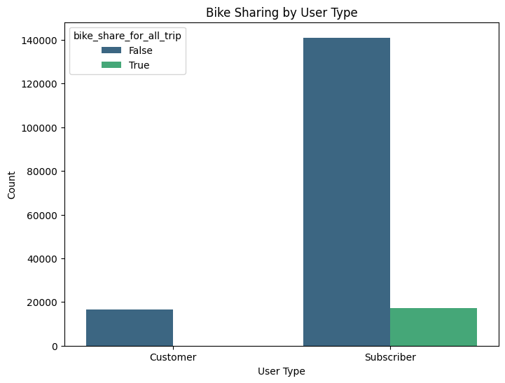

```python
# Clustered bar chart of bike sharing by user type
countplotter('user_type', df_clean, 'bike_share_for_all_trip', 'Bike Sharing by User Type', 'User Type', 'Count')
```

#### Observations:

- Subscribers are more likely to share their bikes for the entire trip compared to customers. However, the majority of both user types did not share their bikes for the entire trip.
- Customers didn't share their bikes at all.

### Question 4: How does member gender vary with user type?

#### Visualization:

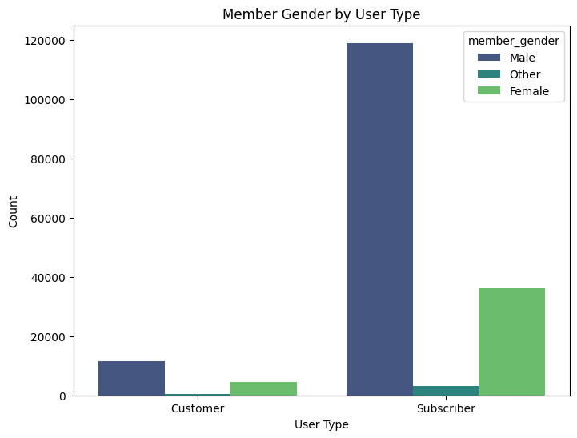

```python
# Clustered bar chart of member gender by user type
countplotter('user_type', df_clean, 'member_gender', 'Member Gender by User Type', 'User Type', 'Count')
```

#### Observations:

- The distribution of member gender is similar for both user types, with a higher count of male members. The "Other" gender category has the lowest count in both user types.

### Question 5: How does the average duration of bike trips vary across different days of the week?

#### Visualization:

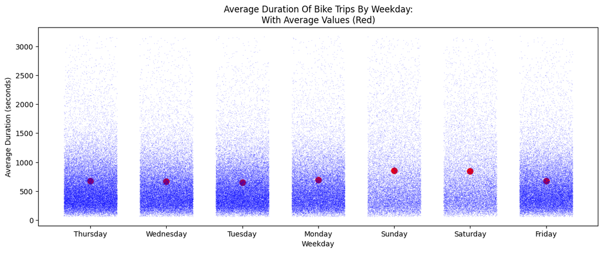

```python
# Extract the weekday from start_time
df_clean['weekday'] = df_clean['start_time'].dt.day_name()

# Calculate the average duration per weekday
avg_duration_per_weekday = df_clean.groupby('weekday')['duration_sec'].mean().reset_index()

# Ensure the weekdays are in the correct order
weekday_order = ['Monday', 'Tuesday', 'Wednesday', 'Thursday', 'Friday', 'Saturday', 'Sunday']
avg_duration_per_weekday['weekday'] = pd.Categorical(avg_duration_per_weekday['weekday'], categories=weekday_order, ordered=True)
avg_duration_per_weekday = avg_duration_per_weekday.sort_values('weekday')

# Plot the data
# create the first axes
fig, ax = plt.subplots(nrows=1, ncols=1, figsize=[14, 5]);

sns.stripplot(data = df_clean.query('duration_sec<duration_sec.quantile(0.99)'), x='weekday', y = 'duration_sec',
              color='b', size=1,jitter=0.35, ax=ax, alpha=0.2)

sns.scatterplot(data = avg_duration_per_weekday, x = 'weekday', y = 'duration_sec', s=100, color='red', ax=ax)
plt.title('Average Duration Of Bike Trips by Weekday:\nWith Average values (Red)'.title())
plt.xlabel('Weekday')
plt.ylabel('Average Duration (seconds)');
```

#### Observations

1. **Weekend vs. Weekday Durations:**
   - The average duration of bike trips is notably higher on weekends (Saturday and Sunday) compared to weekdays. This suggests that people might be taking longer leisure trips during the weekends.
2. **Consistent Weekday Durations:**
   - During weekdays (Monday to Friday), the average duration of bike trips is relatively consistent, ranging between 650 to 750 seconds. This indicates that weekday trips are shorter and possibly more routine or commuting-focused.

### Talk about some of the relationships you observed in this part of the investigation. How did the feature(s) of interest vary with other features in the dataset?

- **Trip Duration and User Type:** The box plot shows that subscribers generally have shorter trip durations compared to customers. This could indicate that subscribers use the service for shorter, more frequent trips, while customers might be using it for longer, occasional rides.
- **Bike Sharing and User Type:** The clustered bar chart reveals that subscribers are more likely to share their bikes for the entire trip than customers. This behavior might be influenced by the frequency and nature of trips taken by subscribers.
- **Trip Duration and weekends:** The average duration of bike trips is significantly higher on weekends (Saturday and Sunday) compared to weekdays. This suggests that people tend to take longer trips during the weekends, possibly for leisure activities.
- **Trip Duration and weekdays:** During weekdays (Monday to Friday), the average duration of bike trips is relatively consistent, indicating that these trips are likely for commuting or other routine purposes.

### Did you observe any interesting relationships between the other features (not the main feature(s) of interest)?

These bivariate explorations provide valuable insights into the relationships between different features in the dataset, highlighting areas for further analysis and potential interventions to improve the bike-sharing service.

## Multivariate Exploration

To conduct a thorough multivariate exploration, I'll create several visualizations to analyze the relationships between multiple variables. Here are some questions and corresponding visualizations:

### Question 1: How does trip duration vary by user type and day of the week?

#### Visualization: Facet Grid

We'll use a Facet Grid to visualize how trip durations differ between "Customer" and "Subscriber" user types across different days of the week.

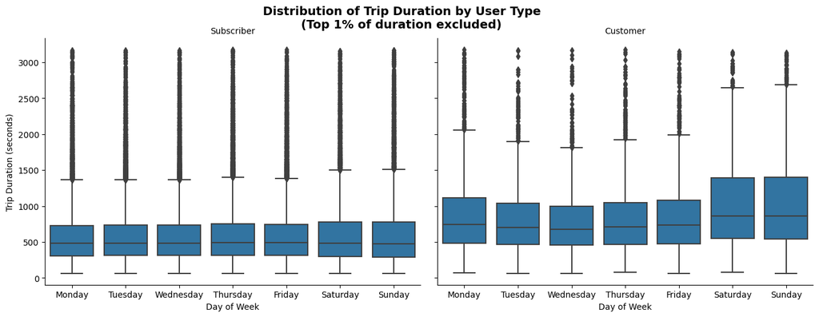

```python
# Plot with outliers excluded
df_clean['day_of_week'] = df_clean['start_time'].dt.day_name()

g = sns.FacetGrid(df_clean.query('duration_sec<duration_sec.quantile(0.99)'), col="user_type", col_wrap=2, height=5)
g.map(sns.boxplot, 'day_of_week', 'duration_sec', order=days_order)
g.set_titles("{col_name}")
g.set_axis_labels('Day of Week', 'Trip Duration (seconds)')
# Set Plot Dimensions - FIGURE LEVEL
g.fig.set_size_inches(14, 5)
plt.suptitle('Distribution of Trip Duration by User Type\n(Top 1% of duration excluded)', y=1.04, fontsize=14, weight='bold')
plt.show()
```

#### Observations:

- **Subscribers** tend to have more consistent trip durations across days of the week compared to **Customers**.
- **Customers** might show more variability, potentially indicating more occasional or irregular use patterns.

### Question 2: What is the relationship between trip duration and age, categorized by bike share status?

#### Visualization: Scatterplot with Hue

We'll use a scatterplot to investigate the relationship between trip duration and user age, color-coded by whether the trip was part of the bike share program.

```python
df_clean.head()
```

|  | duration_sec | start_time | end_time | start_station_id | start_station_name | start_station_latitude | start_station_longitude | end_station_id | end_station_name | end_station_latitude | end_station_longitude | bike_id | user_type | member_birth_year | member_gender | bike_share_for_all_trip | weekday | day_of_week |
| --- | --- | --- | --- | --- | --- | --- | --- | --- | --- | --- | --- | --- | --- | --- | --- | --- | --- | --- |
| 0 | 52185 | 2019-02-28 17:32:10.145 | 2019-03-01 08:01:55.975 | 21 | Montgomery St BART Station (Market St at 2nd St) | 37.789625 | -122.400811 | 13 | Commercial St at Montgomery St | 37.794231 | -122.402923 | 4902 | Customer | 1984 | Male | False | Thursday | Thursday |
| 2 | 61854 | 2019-02-28 12:13:13.218 | 2019-03-01 05:24:08.146 | 86 | Market St at Dolores St | 37.769305 | -122.426826 | 3 | Powell St BART Station (Market St at 4th St) | 37.786375 | -122.404904 | 5905 | Customer | 1972 | Male | False | Thursday | Thursday |
| 3 | 36490 | 2019-02-28 17:54:26.010 | 2019-03-01 04:02:36.842 | 375 | Grove St at Masonic Ave | 37.774836 | -122.446546 | 70 | Central Ave at Fell St | 37.773311 | -122.444293 | 6638 | Subscriber | 1989 | Other | False | Thursday | Thursday |
| 4 | 1585 | 2019-02-28 23:54:18.549 | 2019-03-01 00:20:44.074 | 7 | Frank H Ogawa Plaza | 37.804562 | -122.271738 | 222 | 10th Ave at E 15th St | 37.792714 | -122.248780 | 4898 | Subscriber | 1974 | Male | True | Thursday | Thursday |
| 5 | 1793 | 2019-02-28 23:49:58.632 | 2019-03-01 00:19:51.760 | 93 | 4th St at Mission Bay Blvd S | 37.770407 | -122.391198 | 323 | Broadway at Kearny | 37.798014 | -122.405950 | 5200 | Subscriber | 1959 | Male | False | Thursday | Thursday |

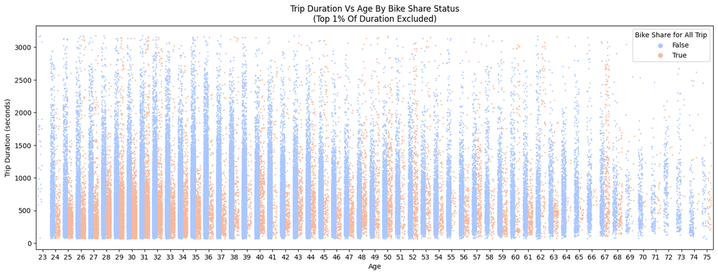

```python
df_clean['age'] = 2024 - df_clean['member_birth_year']  # Assuming current year is 2024

# Plot
plt.figure(figsize=(18, 6))
sns.stripplot(data=df_clean.query('duration_sec<duration_sec.quantile(0.99) and age<=75'),
              x='age', y='duration_sec', hue='bike_share_for_all_trip', palette='coolwarm',
              size=2, jitter=0.35, dodge=True)
plt.xlabel("Age")
plt.ylabel("Trip Duration (seconds)")
plt.title("Trip Duration vs Age by Bike Share Status\n(Top 1% of duration excluded)".title())
plt.legend(title='Bike Share for All Trip')
plt.show()
```

### Question 3: How does the distribution of trip durations vary by gender and user type?

#### Visualization: Violin Plot

We'll use a violin plot to visualize the distribution of trip durations for different genders and user types.

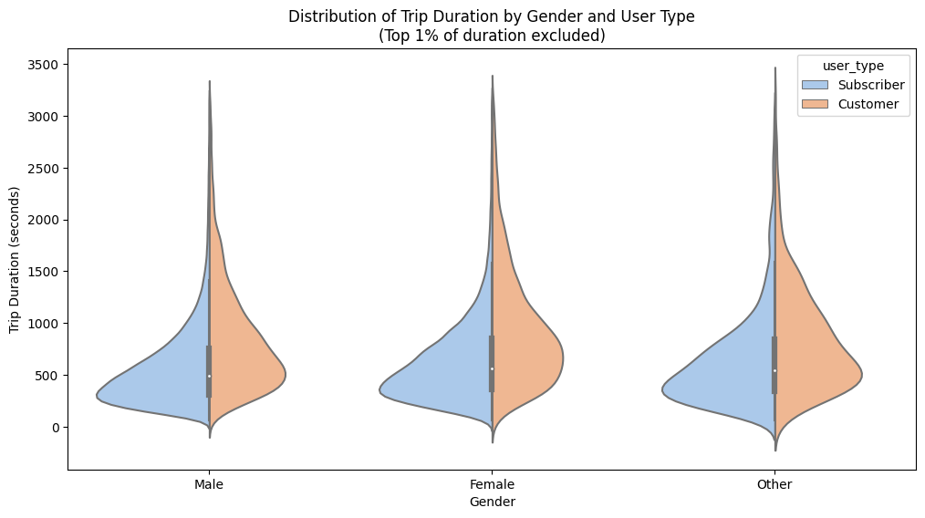

```python
# Violin plot excluding top 1% of durations
plt.figure(figsize=(12, 6))
sns.violinplot(data=df_clean.query('duration_sec<duration_sec.quantile(0.99)'), x='member_gender', y='duration_sec', hue='user_type', split=True, palette='pastel')
plt.xlabel("Gender")
plt.ylabel("Trip Duration (seconds)")
plt.title("Distribution of Trip Duration by Gender and User Type\n(Top 1% of duration excluded)")
plt.show()
```

#### Observations:

- The distribution may show differences in trip duration between genders and user types.
- Any significant discrepancies might reveal patterns in how different demographics use bike services.

### Talk about some of the relationships you observed in this part of the investigation. Were there features that strengthened each other in terms of looking at your feature(s) of interest?

- **User Type and Trip Duration:** Observing trip duration in relation to user type helps us understand usage patterns. For instance, Subscribers might have more predictable trip durations compared to Customers, possibly indicating regular commuting vs. occasional use.
- **Age and Trip Duration:** Analyzing the relationship between age and trip duration helps identify how different age groups use the bike share system, with potentially younger users taking longer trips.

### Were there any interesting or surprising interactions between features?

These insights help in understanding user behavior and can be valuable for optimizing bike share services and planning improvements.

## Conclusions

**Steps Taken:**

1. **Data Cleaning:** Handled missing values by removing rows with null values, corrected data types for consistency, and mapped categorical values to appropriate types.
2. **Exploratory Analysis:** Conducted univariate and bivariate analysis to understand distributions and relationships between key features such as trip duration, user type, and bike sharing status.
3. **Visualizations:** Utilized various plots (histograms, heatmaps, box plots) to explore and interpret data distributions and relationships, including temporal and geographic patterns.

These insights reveal key patterns in bike usage and user behaviors, which can inform strategies for improving the bike-sharing service and addressing user needs.

```python
df_clean.to_csv('201902-fordgobike-tripdata-cleaned.csv', index=False)
```